# ELMER: An R/Bioconductor Tool Inferring Regulatory Element Landscapes and Transcription Factor Networks Using Methylomes

### Nearby Probes

Generate schematic plot for one gene with the probes which the gene is significantly linked to.

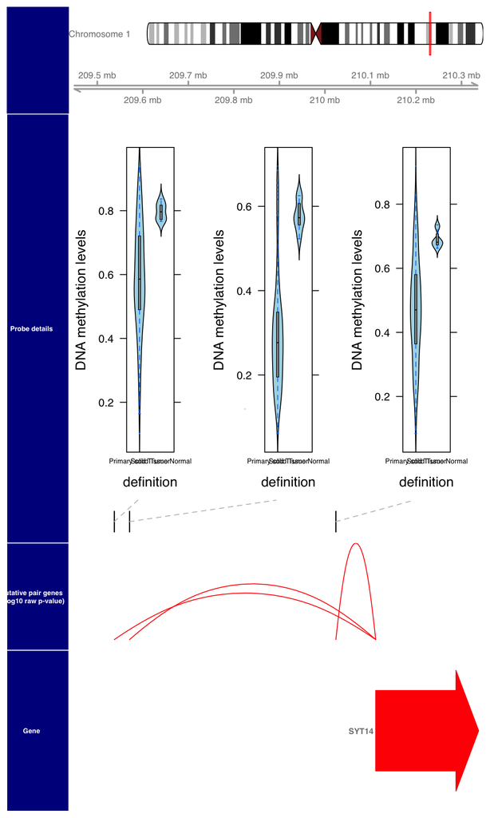

The schematic plot shows the gene colored in red and all blue colored probes, which are significantly linked to the expression of this gene.

```r
pair <- read.csv("result/getPair.hypo.pairs.significant.csv")
schematic.plot(pair = pair,
               data = mae,
               group.col = "definition",
               byGene = "ENSG00000143469",
               save = FALSE)
```

## Motif enrichment plot

Motif enrichment plot shows the enrichment levels for the selected motifs.

The plot shows the Odds Ratio (x axis) for the selected motifs with OR above 1.3 and lower boundary of OR above 1.3. The range shows the 95% confidence interval for each Odds Ratio

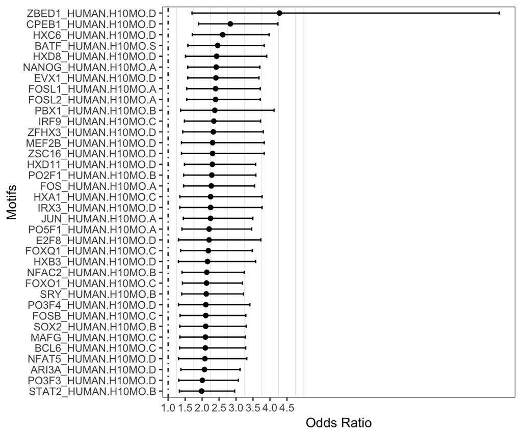

The plot shows the Odds Ratio (x axis) for the selected motifs with OR above 1.3 and lower boundary of OR above 1.3. The range shows the 95% confidence interval for each Odds Ratio.

```r
motif.enrichment.plot(motif.enrichment = "result/getMotif.hypo.motif.enrichment.csv",
                      significant = list(OR = 1.3,lowerOR = 1.3),
                      label = "hypo",
                      save = TRUE)  ## different signficant cut off.
```